# Quality Control

2018-08-09

```r
# Last modified 2018-07-29
bcbioRNASeq::prepareRNASeqTemplate()
source("_setup.R")

# Directory paths ==============================================================
invisible(mapply(
    FUN = dir.create,
    path = c(params$data_dir, params$results_dir),
    MoreArgs = list(showWarnings = FALSE, recursive = TRUE)
))

# Load object ==================================================================
bcb_name <- load(params$bcb_file)
bcb <- get(bcb_name, inherits = FALSE)
stopifnot(is(bcb, "bcbioRNASeq"))
invisible(validObject(bcb))
```

# Overview

```r
> # getMethod("sampleData", "SummarizedExperiment")
> sample_data <- sampleData(bcb, clean = TRUE) %>% as.data.frame()
> write.csv(
+     x = sample_data,
+     file = file.path(params$results_dir, "sample_data.csv")
+ )
> sample_data
```

|  | sampleName | group |
| --- | --- | --- |
| group1_1 | group1_1 | ctrl |
| group1_2 | group1_2 | ctrl |
| group2_1 | group2_1 | ko |
| group2_2 | group2_2 | ko |

[bcbio](https://github.com/chapmanb/bcbio-nextgen) run data was imported from **/home/travis/build/hbc/bcbio_rnaseq_output_example**.

# Count matrices

```r
> # getMethod("counts", "bcbioRNASeq")
>
> # Raw counts (don't use for plotting)
> raw_counts <- counts(bcb, normalized = FALSE)
>
> # DESeq2 normalized counts
> normalized_counts <- counts(bcb, normalized = TRUE)
>
> # Transcripts per million
> tpm <- counts(bcb, normalized = "tpm")
>
> saveData(raw_counts, normalized_counts, tpm, dir = params$data_dir)
```

```
## Saving raw_counts.rda, normalized_counts.rda, tpm.rda to /home/travis/build/hbc/bcbio_rnaseq_output_example/report/data
```

```r
> writeCounts(raw_counts, normalized_counts, tpm, dir = params$results_dir)
```

```
## Writing raw_counts, normalized_counts, tpm to /home/travis/build/hbc/bcbio_rnaseq_output_example/report/results/2018-08-09/quality_control
```

The results are saved as gzip-compressed comma separated values (CSV). Gzip compression is natively supported on [macOS](https://www.apple.com/macos) and Linux-based operating systems. If you’re running Windows, we recommend installing [7-Zip](http://www.7-zip.org). CSV files can be opened in [Excel](https://products.office.com/en-us/excel) or [RStudio](https://www.rstudio.com).

- `normalized_counts.csv.gz`: Use to evaluate individual genes and/or generate plots. These counts are normalized for the variation in sequencing depth across samples.
- `tpm.csv.gz`: Transcripts per million, scaled by length and also suitable for plotting.
- `raw_counts.csv.gz`: Only use to perform a new differential expression analysis. These counts will vary across samples due to differences in sequencing depth, and have not been normalized. Do not use this file for plotting genes.

# Read metrics

## Total reads

High quality RNA-seq samples ideally should have at least 10 million reads per sample.

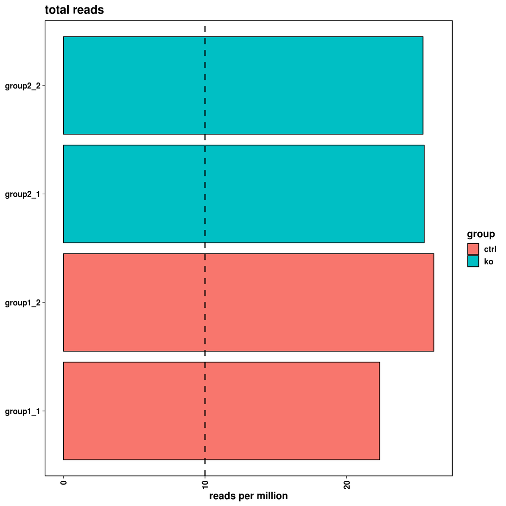

```r
> # getMethod("plotTotalReads", "bcbioRNASeq")
> plotTotalReads(bcb)
```

## Mapped reads

The number of mapped reads should correspond to the number of total reads.

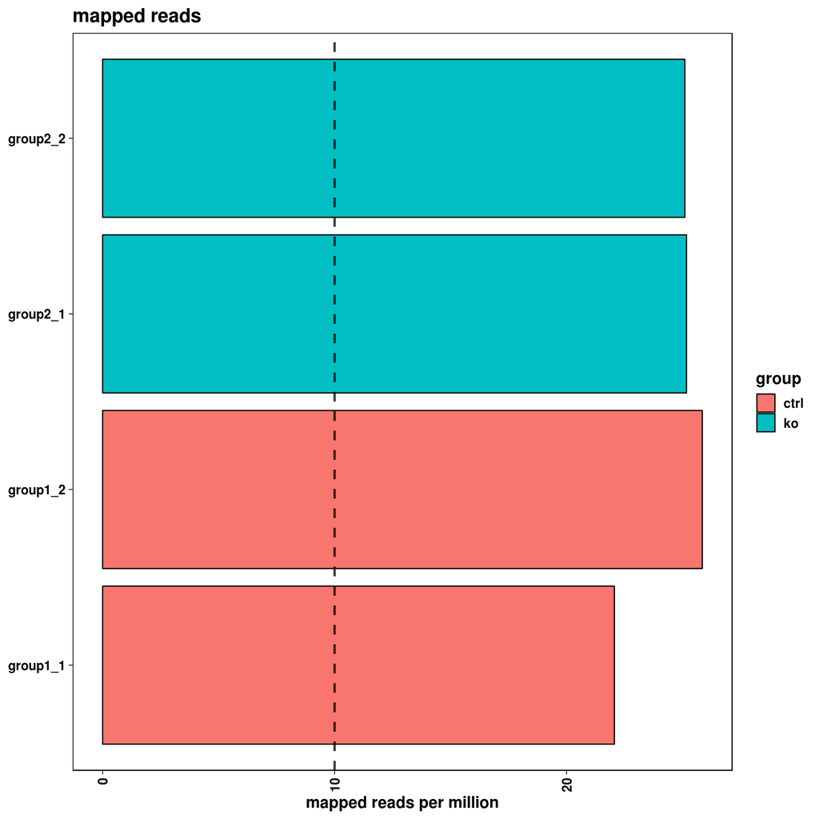

```r
> # getMethod("plotMappedReads", "bcbioRNASeq")
> plotMappedReads(bcb)
```

## Mapping rate

The genomic mapping rate represents the percentage of reads mapping to the reference genome. Low mapping rates are indicative of sample contamination, poor sequencing quality or other artifacts.

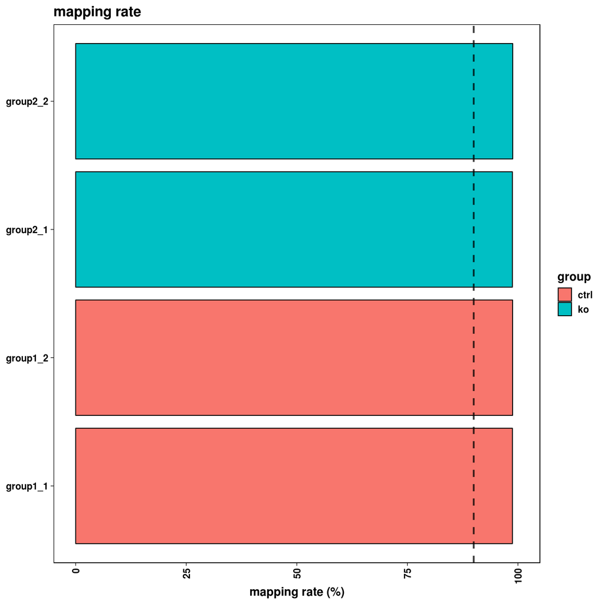

```r
> # getMethod("plotMappingRate", "bcbioRNASeq")
> plotMappingRate(bcb)
```

## Number of genes detected

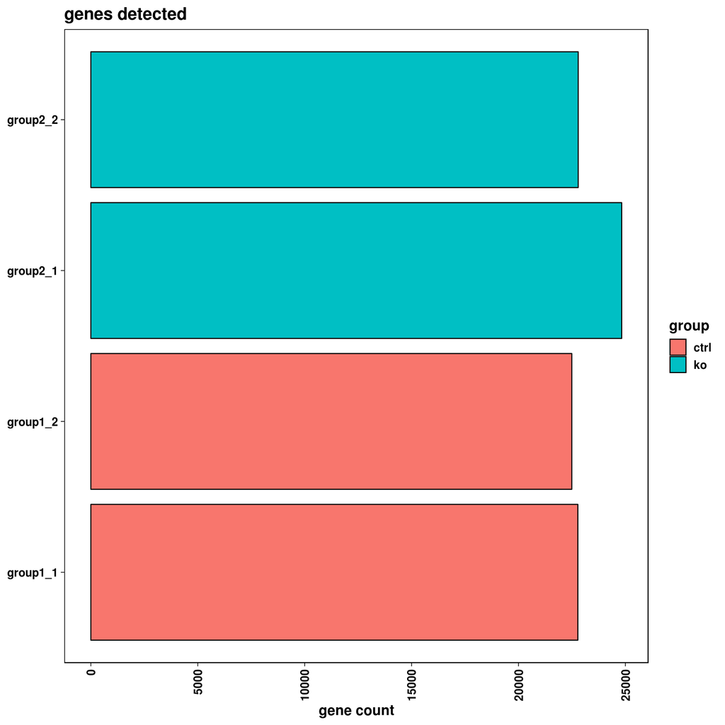

```r
> # getMethod("plotGenesDetected", "bcbioRNASeq")
> plotGenesDetected(bcb)
```

## Gene detection saturation

We should observe a linear trend in the number of genes detected with the number of mapped reads, which indicates that the sample input was not overloaded.

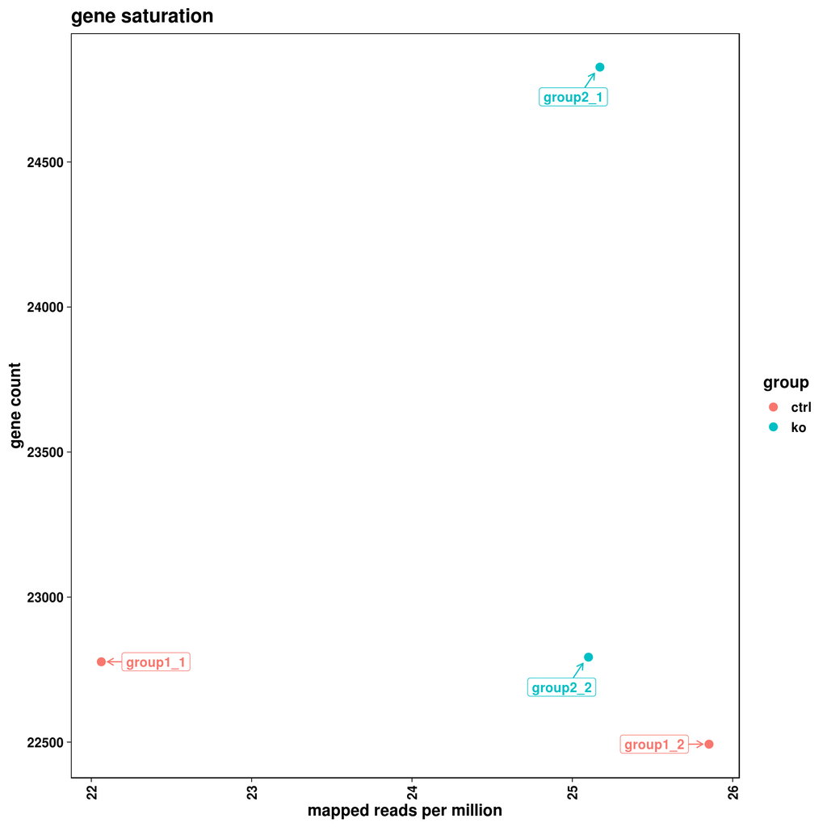

```r
> # getMethod("plotGeneSaturation", "bcbioRNASeq")
> plotGeneSaturation(bcb, label = TRUE)
```

## Exonic mapping rate

Ideally, at least 60% of total reads should map to exons.

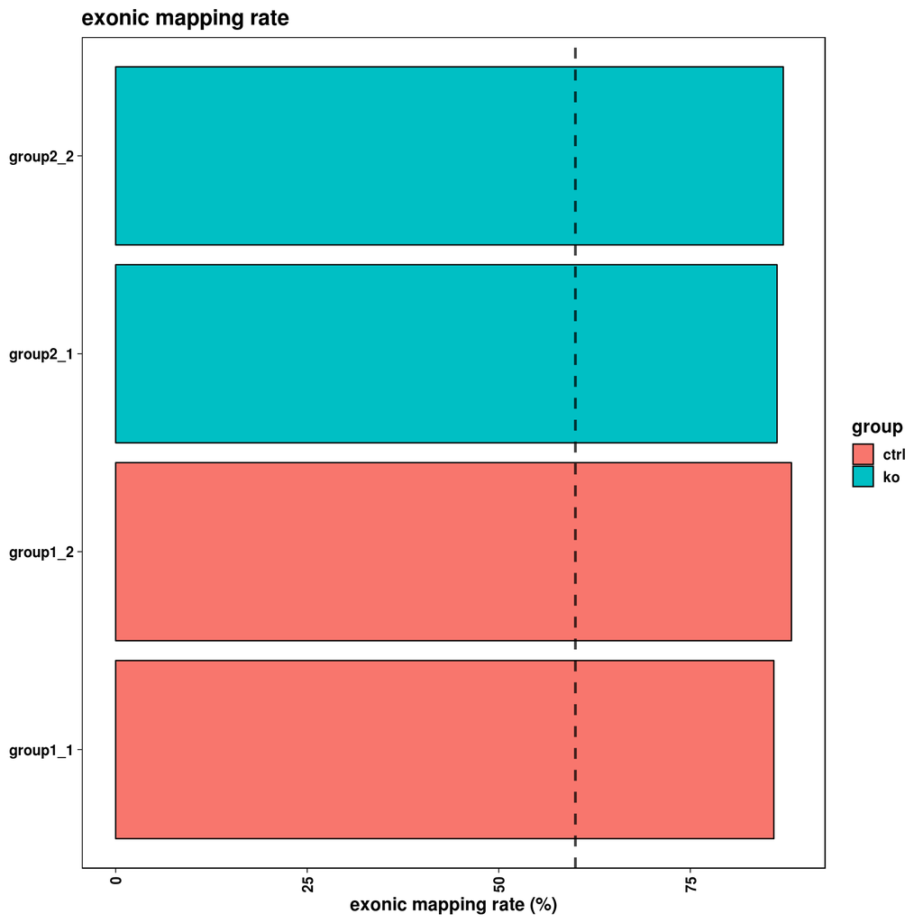

```r
> # getMethod("plotExonicMappingRate", "bcbioRNASeq")
> plotExonicMappingRate(bcb)
```

## Intronic mapping rate

The majority of reads should map to exons and not introns.

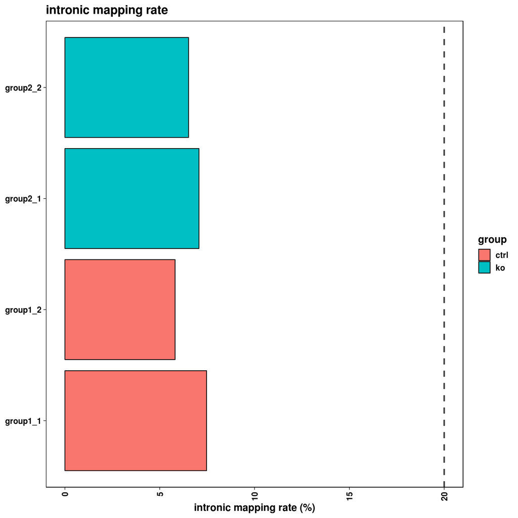

```r
> # getMethod("plotIntronicMappingRate", "bcbioRNASeq")
> plotIntronicMappingRate(bcb)
```

## rRNA mapping rate

Samples should have a ribosomal RNA (rRNA) contamination rate below 10%.

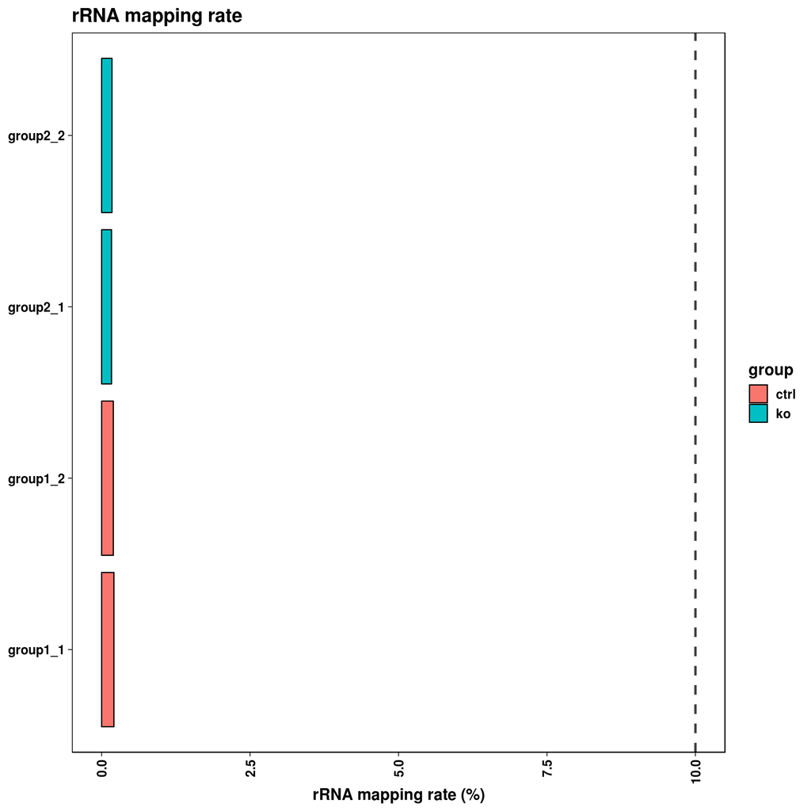

```r
> # getMethod("plotRRNAMappingRate", "bcbioRNASeq")
> plotRRNAMappingRate(bcb)
```

## 5’->3’ bias

RNA-seq data can have specific biases at either the 5’ or 3’ end of sequenced fragments. It is common to see a small amount of bias, especially if polyA enrichment was performed, or if there is any sample degradation. If a large amount of bias is observed here, be sure to analyze the samples with a Bioanalyzer and check the RIN scores.

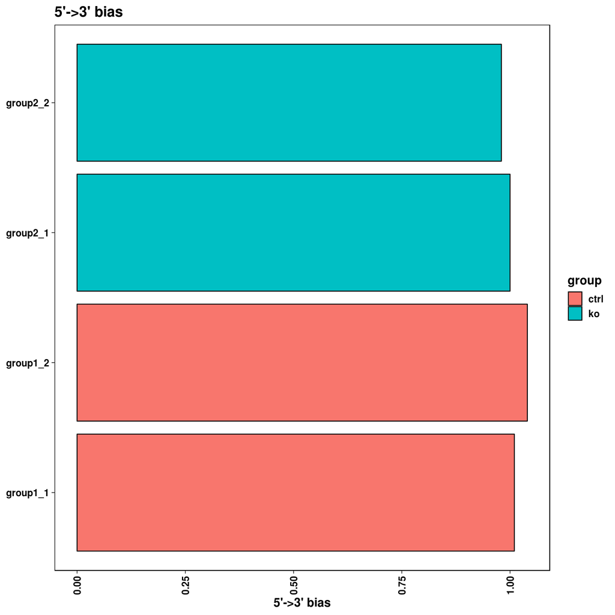

```r
> # getMethod("plot5Prime3PrimeBias", "bcbioRNASeq")
> plot5Prime3PrimeBias(bcb)
```

## Counts per gene

Generally, we expect similar count spreads for all genes between samples unless the library sizes or total RNA expression are different.

We recommend visualizing counts normalized with the Trimmed Mean of M-Values (TMM) method here (Robinson and Oshlack 2010). TMM normalization equates the overall expression levels of genes between samples under the assumption that the majority of them are not differentially expressed. Therefore, by normalizing for total RNA expression by sample, we expect the spread of the TMM-normalized counts per gene to be similar for every sample.

```
## 29858 non-zero genes detected
```

```
## Applying trimmed mean of M-values (TMM) normalization
```

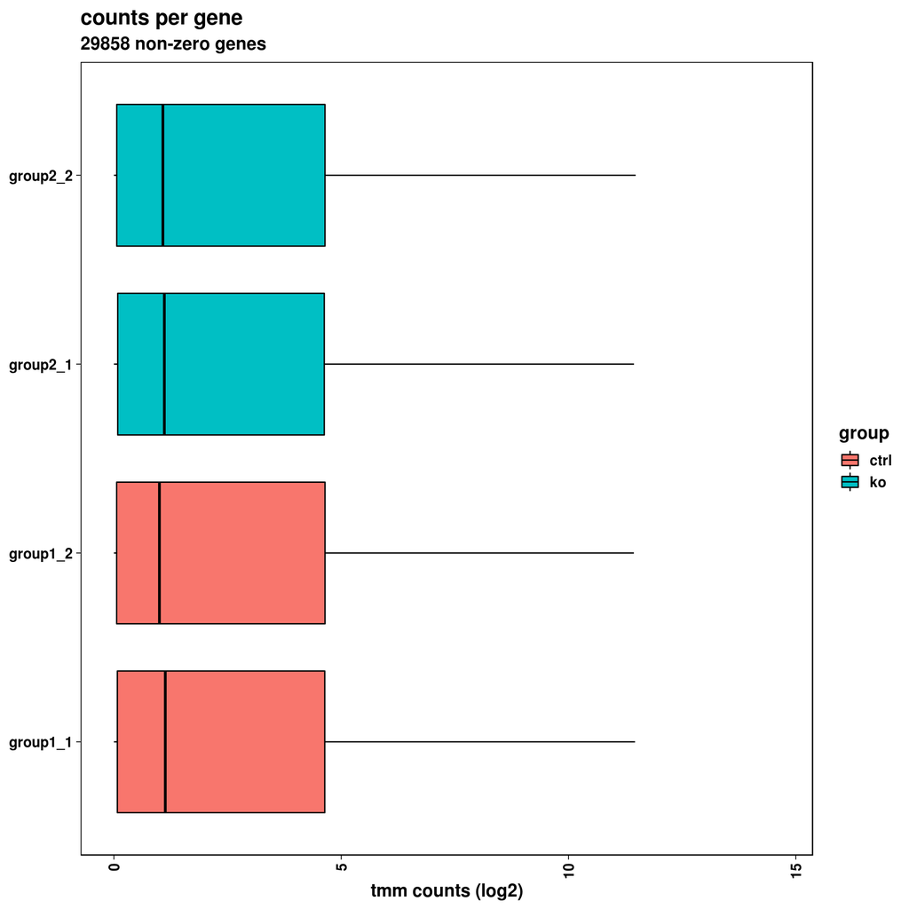

```r
> # getMethod("plotCountsPerGene", "bcbioRNASeq")
> plotCountsPerGene(bcb, normalized = "tmm")
```

## TPM per biotype

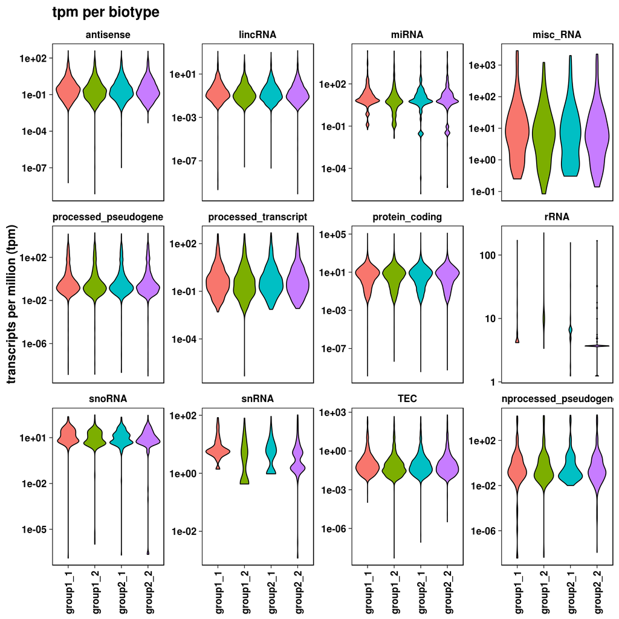

## TPM per broad biotype class

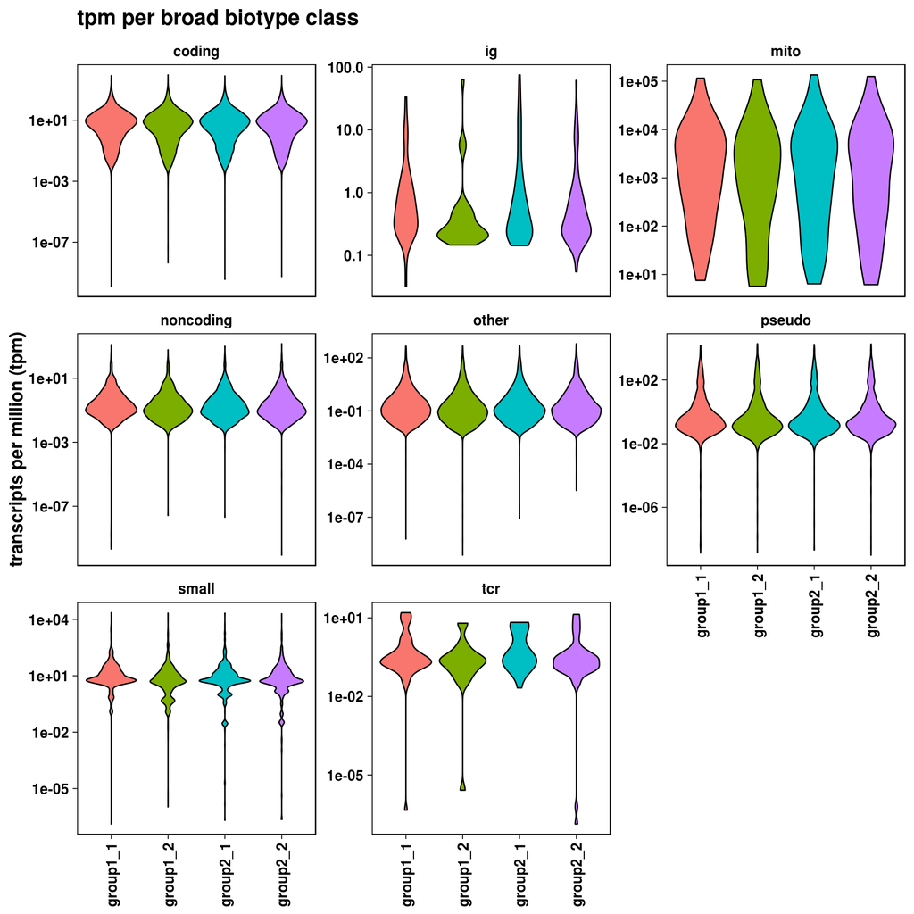

## Count density

Generally, we expect similar count spreads for all genes between samples unless the total expressed RNA per sample is different.

```
## 29858 non-zero genes detected
```

```
## Applying trimmed mean of M-values (TMM) normalization
```

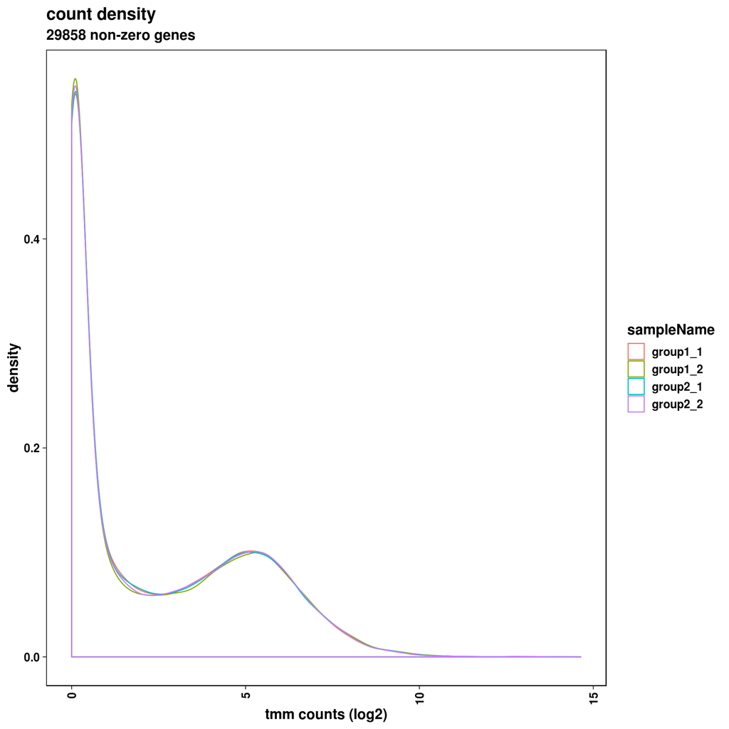

```r
> # getMethod("plotCountDensity", "bcbioRNASeq")
> plotCountDensity(
+     object = bcb,
+     interestingGroups = "sampleName",
+     normalized = "tmm"
+ )
```

# Fit modeling

Several quality metrics are first assessed to explore the fit of the model, before differential expression analysis is performed.

## Dispersion

The following plot shows the dispersion by mean of normalized counts. We expect the dispersion to decrease as the mean of normalized counts increases.

```
## Coercing bcbioRNASeq to DESeqDataSet with DESeq2 1.20.0
```

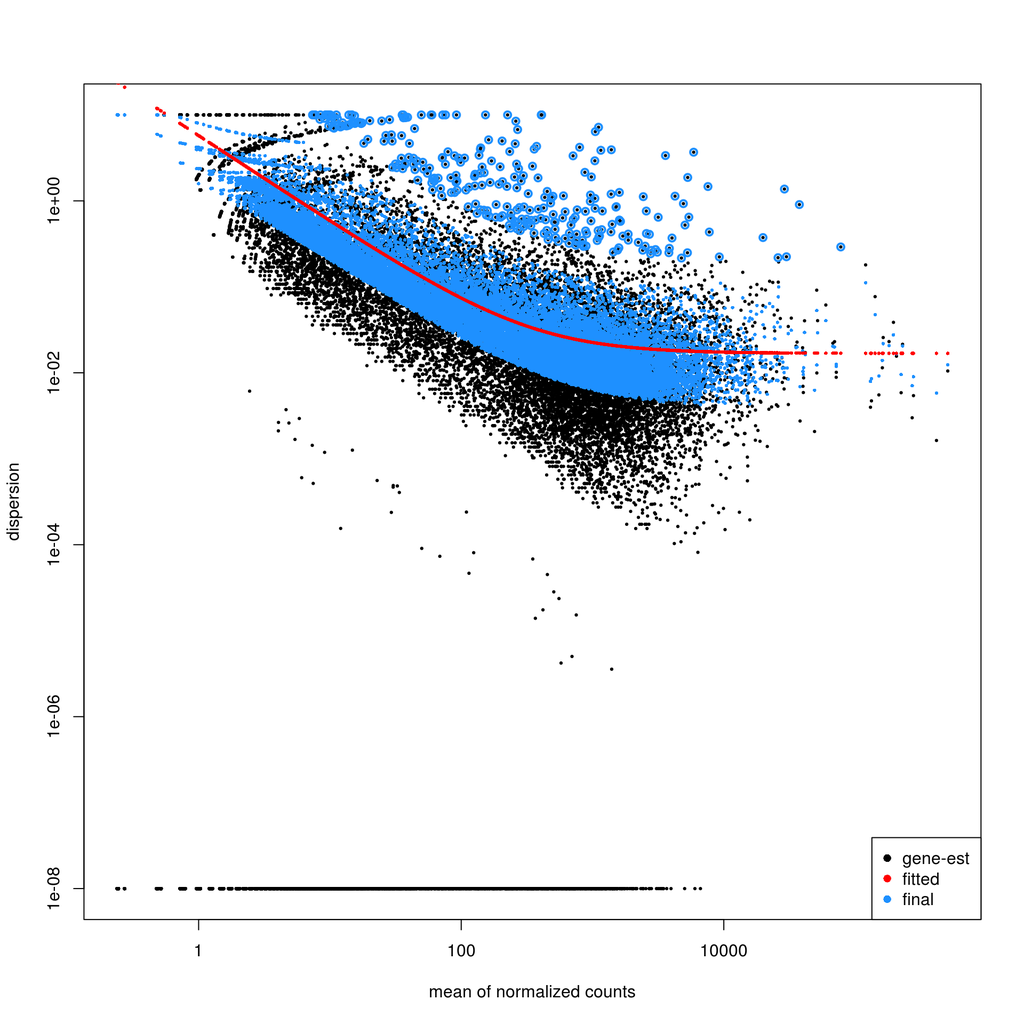

```r
> # getMethod("plotDispEsts", "bcbioRNASeq")
> plotDispEsts(bcb)
```

## Variance stabilization

```
## Skipping regularized log
```

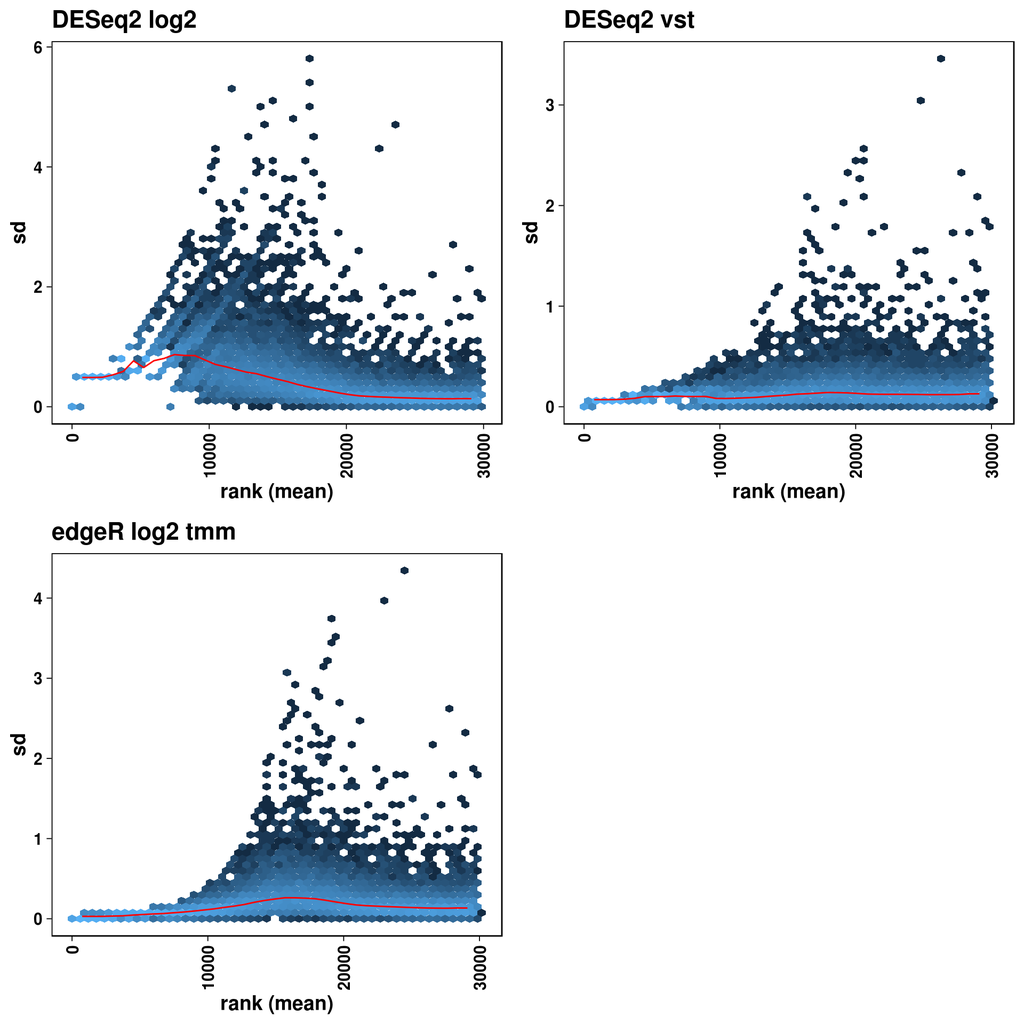

```r
> # getMethod("plotMeanSD", "bcbioRNASeq")
> plotMeanSD(bcb)
```

# Sample similarity analysis

## Principal component analysis (PCA)

PCA (Jolliffe 2002) is a multivariate technique that allows us to summarize the systematic patterns of variations in the data. PCA takes the expression levels for genes and transforms it in principal component space, reducing each sample into one point. Thereby, we can separate samples by expression variation, and identify potential sample outliers. The PCA plot is a way to look at how samples are clustering.

```
## Using vst counts
```

```
## Plotting PCA using 500 genes
```

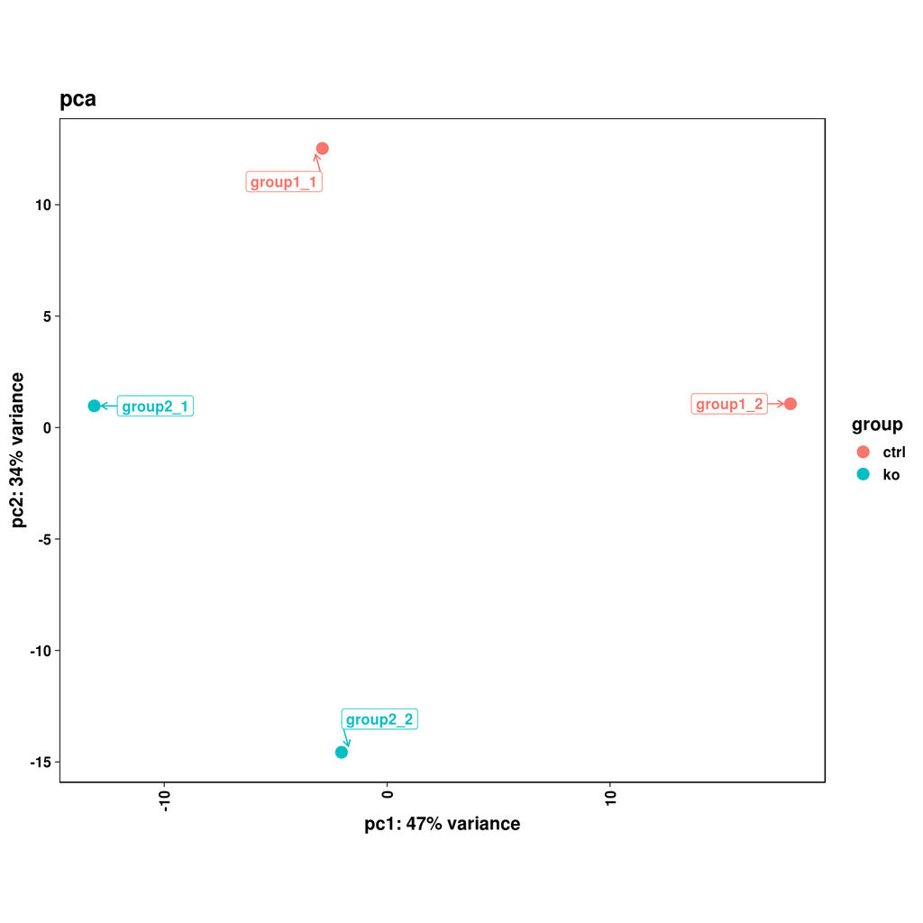

```r
> # getMethod("plotPCA", "bcbioRNASeq")
> plotPCA(
+     object = bcb,
+     normalized = "vst",
+     label = TRUE
+ )
```

## Covariates correlation with PCs

```
##
## running pca and calculating correlations for:
## un-scaled  data in pca;
## pve >= 5%;
## kendall cor
```

[figure not shown]

```r
> # getMethod("plotPCACovariates", "bcbioRNASeq")
> plotPCACovariates(bcb)
```

## Hierarchical clustering

Inter-correlation analysis (ICA) is another way to look at how well samples cluster by plotting the correlation between the expression profiles of the samples.

```
## Using vst counts
```

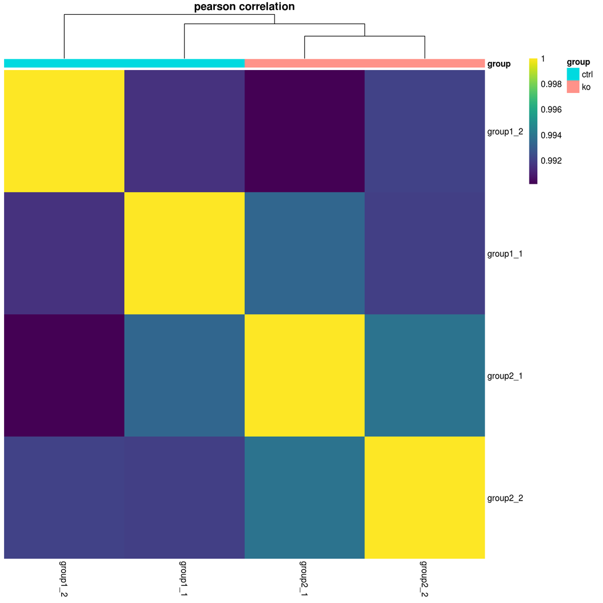

```r
> # getMethod("plotCorrelationHeatmap", "bcbioRNASeq")
> plotCorrelationHeatmap(bcb, normalized = "vst")
```

# Save additional data

## Quality metrics

```r
> metrics <- metrics(bcb)
> write.csv(
+     x = metrics,
+     file = file.path(params$results_dir, "metrics.csv")
+ )
```

## Gene annotations

```r
> gene_annotations <- rowRanges(bcb) %>% as.data.frame()
> write.csv(
+     x = gene_annotations,
+     file = file.path(params$results_dir, "gene_annotations.csv")
+ )
```

# Methods

RNA-seq counts were generated by [bcbio](https://github.com/chapmanb/bcbio-nextgen) and bcbioRNASeq using [Salmon](https://combine-lab.github.io/salmon) (Patro et al. 2017). Counts were imported into [R](https://www.r-project.org) using [tximport](https://bioconductor.org/packages/release/bioc/html/tximport.html) (Soneson, Love, and Robinson 2016) and [DESeq2](https://bioconductor.org/packages/release/bioc/html/DESeq2.html) (Love, Huber, and Anders 2014). Gene annotations were obtained from [Ensembl](https://www.ensembl.org). Plots were generated by [ggplot2](http://ggplot2.org) (Wickham 2009). Heatmaps were generated by [pheatmap](https://cran.r-project.org/web/packages/pheatmap/index.html) (Kolde 2015).

# R session information

```r
> markdownHeader("YAML params", level = 2)
```

## YAML params

```r
> print(params)
```

```
## $results_dir
## [1] "results/2018-08-09/quality_control"
##
## $bcb_file
##                                                                      bcb
## "/home/travis/build/hbc/bcbio_rnaseq_output_example/report/data/bcb.rda"
##
## $data_dir
## [1] "data"
```

```r
> markdownHeader("`_setup.R`", level = 2)
```

## `_setup.R`

```r
> readr::read_lines("_setup.R") %>% writeLines()
```

```
## library(bcbioRNASeq)
## library(DESeq2)
## library(DEGreport)
## library(knitr)
## library(tidyverse)
##
## # Set seed for reproducibility
## set.seed(1454944673L)
##
## opts_chunk[["set"]](
##     autodep = TRUE,
##     bootstrap.show.code = FALSE,
##     cache = TRUE,
##     cache.lazy = TRUE,
##     dev = c("png", "pdf"),
##     fig.height = 10L,
##     fig.retina = 2L,
##     fig.width = 10L,
##     highlight = TRUE,
##     prompt = TRUE,
##     tidy = FALSE
## )
##
## theme_set(
##     theme_paperwhite(
##         base_size = 14L,
##         legend_position = "right"
##     )
## )
```

```r
> markdownHeader("`sessioninfo::session_info()`", level = 2)
> markdownHeader("`utils::sessionInfo()`", level = 2)
```

[output not shown]

Jolliffe, Ian. 2002. *Principal component analysis*. Wiley Online Library.

Kolde, Raivo. 2015. *Pheatmap: Pretty Heatmaps*. https://CRAN.R-project.org/package=pheatmap.

Love, Michael I, Wolfgang Huber, and Simon Anders. 2014. “Moderated Estimation of Fold Change and Dispersion for RNA-seq Data with DESeq2.” *Genome Biol.* 15 (12): 550. https://doi.org/10.1186/s13059-014-0550-8.

Patro, Rob, Geet Duggal, Michael I Love, Rafael A Irizarry, and Carl Kingsford. 2017. “Salmon Provides Fast and Bias-Aware Quantification of Transcript Expression.” *Nat. Methods* 14 (4): 417–19. https://doi.org/10.1038/nmeth.4197.

Robinson, Mark D, and Alicia Oshlack. 2010. “A Scaling Normalization Method for Differential Expression Analysis of RNA-seq Data.” *Genome Biol.* 11 (3): R25. https://doi.org/10.1186/gb-2010-11-3-r25.

Soneson, Charlotte, Michael I Love, and Mark D Robinson. 2016. “Differential Analyses for RNA-seq: Transcript-Level Estimates Improve Gene-Level Inferences.” *F1000Res.* 4 (December). https://doi.org/10.12688/f1000research.7563.1.

Wickham, Hadley. 2009. *Ggplot2: Elegant Graphics for Data Analysis*. Use R. Springer New York. https://doi.org/10.1007/978-0-387-98141-3.